[O’Hara on GitHub](https://github.com/oharac)

# Plot species impact trends

Compiled on Sat May 2 15:04:21 2020 by ohara

```r
library(raster)
library(sf)
source('https://raw.githubusercontent.com/oharac/src/master/R/common.R')

source(here('common_fxns.R'))
```

# 1 Summary

Here we plot species impact trends - how impacted range area is changing over time. We can look at this on a stressor-by-stressor basis, and grouped by cumulative stressors by category.

## 1.1 Methods summary

Read in all the impact summaries. Attach taxonomic information and range information.

For each stressor, calculate impact trends by taxon, by range size, and overall.

- Impact trend will be change in percent impacted range?
- or absolute? This devalues small-ranged species. Perhaps in the range size calculations.

# 2 Methods

## 2.1 Get impact summaries

Load the impact summaries, attach info on taxonomic groupings and range quintiles.

## 2.2 Summarize by stressor

Note, trends are based only on the species with reported sensitivity - i.e. non-sensitive species are dropped. More conservative perhaps would be to include these species as having constant zero-impact ranges.

### 2.2.1 Stressor on individual species

Prioritize species by stressor based on percent impact and range:

$$\text{priority} = \frac{\text{% range impacted}}{\ln (\text{spp range, km}^2)}$$

The $\ln (\text{spp range, km}^2)$ term reduces priority for large-ranged species and emphasizes small-ranged endemics, even for the same proportion of impacted range.

Here we will not summarize by every stressor, but just the cumulative category levels. The priority will be based on the average impact over the most recent three years of impacts.

Note that not all included species are represented in the `priority_by_stressor` dataframe - some species listed as threatened by a stressor may not overlap areas where that stressor is significantly occurring according to our data.

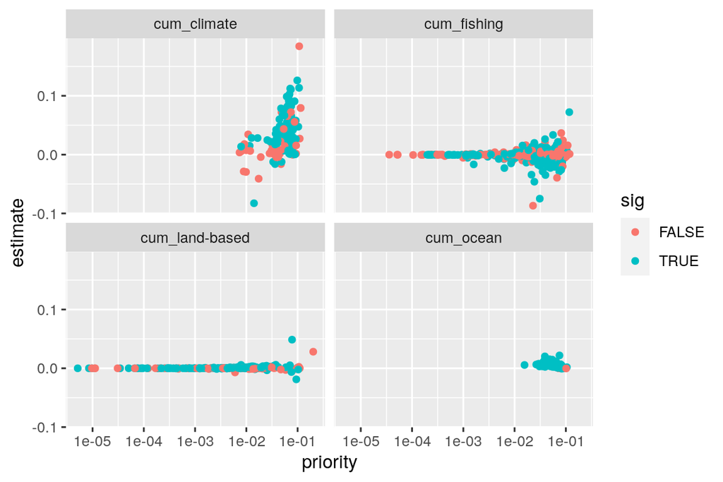

### 2.2.2 Stressor on all impacted spp

|  | stressor | adj_r2 | term | estimate | std.error | statistic | p.value |
| --- | --- | --- | --- | --- | --- | --- | --- |
| 1 | art_fish | -0.000127336561325242 | (Intercept) | 0.46862 | 1.65943 | 0.2824 | 0.77765 |
| 2 | art_fish | -0.000127336561325242 | year | 0 | 0.00083 | -0.0051 | 0.99593 |
| 3 | cum_climate | 0.128627404291012 | (Intercept) | -47.90597 | 1.72287 | -27.80595 | 0 |
| 4 | cum_climate | 0.128627404291012 | year | 0.02425 | 0.00086 | 28.26407 | 0 |
| 5 | cum_fishing | -0.000105759917894632 | (Intercept) | 0.44357 | 1.69481 | 0.26172 | 0.79354 |
| 6 | cum_fishing | -0.000105759917894632 | year | 3e-05 | 0.00084 | 0.03149 | 0.97488 |
| 7 | cum_land-based | 8.11473014020736e-05 | (Intercept) | -1.26057 | 1.11136 | -1.13426 | 0.25673 |
| 8 | cum_land-based | 8.11473014020736e-05 | year | 0.00069 | 0.00055 | 1.24159 | 0.21443 |
| 9 | cum_ocean | 0.0347992487258127 | (Intercept) | -11.56326 | 0.92749 | -12.46731 | 0 |
| 10 | cum_ocean | 0.0347992487258127 | year | 0.0061 | 0.00046 | 13.21634 | 0 |

[output cut: 26 more lines]

### 2.2.3 Stressor on impacted spp by range quintile

|  | stressor | qtile | adj_r2 | term | estimate | std.error | statistic | p.value |
| --- | --- | --- | --- | --- | --- | --- | --- | --- |
| 1 | art_fish | 1 | -5.04981759927858e-05 | (Intercept) | 6.95959 | 6.53819 | 1.06445 | 0.28741 |
| 2 | art_fish | 1 | -5.04981759927858e-05 | year | -0.00318 | 0.00326 | -0.97691 | 0.32888 |
| 3 | art_fish | 2 | -0.000409983799722458 | (Intercept) | 3.18567 | 4.30642 | 0.73975 | 0.45957 |
| 4 | art_fish | 2 | -0.000409983799722458 | year | -0.00135 | 0.00214 | -0.63021 | 0.52866 |
| 5 | art_fish | 3 | -0.000273425561458929 | (Intercept) | -1.38547 | 2.78277 | -0.49787 | 0.61863 |
| 6 | art_fish | 3 | -0.000273425561458929 | year | 0.00096 | 0.00139 | 0.69071 | 0.48983 |
| 7 | art_fish | 4 | 0.000392427839397635 | (Intercept) | -1.94034 | 1.79834 | -1.07896 | 0.28073 |
| 8 | art_fish | 4 | 0.000392427839397635 | year | 0.0012 | 0.0009 | 1.34109 | 0.18004 |
| 9 | art_fish | 5 | -0.000618581099824933 | (Intercept) | -0.45434 | 3.08588 | -0.14723 | 0.88297 |
| 10 | art_fish | 5 | -0.000618581099824933 | year | 0.00036 | 0.00154 | 0.23536 | 0.81396 |

[output cut: 166 more lines]

### 2.2.4 Stressor on impacted spp by taxonomic group

|  | stressor | taxon | adj_r2 | term | estimate | std.error | statistic | p.value |
| --- | --- | --- | --- | --- | --- | --- | --- | --- |
| 1 | art_fish | birds | -0.00368953472593847 | (Intercept) | 0.14788 | 11.05542 | 0.01338 | 0.98934 |
| 2 | art_fish | birds | -0.00368953472593847 | year | 6e-05 | 0.00551 | 0.01164 | 0.99072 |
| 3 | art_fish | clupeiformes | -0.0197806508503702 | (Intercept) | 7.80483 | 24.31541 | 0.32098 | 0.74968 |
| 4 | art_fish | clupeiformes | -0.0197806508503702 | year | -0.0036 | 0.01211 | -0.29722 | 0.76763 |
| 5 | art_fish | cone_snails | 0.778615022792588 | (Intercept) | 3.65549 | 0.59259 | 6.16862 | 0.00016 |
| 6 | art_fish | cone_snails | 0.778615022792588 | year | -0.00177 | 0.0003 | -6.01417 | 0.0002 |
| 7 | art_fish | groupers | -0.00348845271493392 | (Intercept) | 4.29642 | 8.4291 | 0.50971 | 0.61075 |
| 8 | art_fish | groupers | -0.00348845271493392 | year | -0.00193 | 0.0042 | -0.45921 | 0.64652 |
| 9 | art_fish | mammals | -0.0027344149533568 | (Intercept) | 2.25273 | 11.37192 | 0.1981 | 0.84308 |
| 10 | art_fish | mammals | -0.0027344149533568 | year | -0.00092 | 0.00566 | -0.16271 | 0.87084 |

[output cut: 298 more lines]